# Trending Youtube Videos

Group 313:2

16/12/2019

## Group Members

Adam Bauer

Kelli Unruh

Charles Saunders

Krishna Jangid

## Introduction

YouTube uses a combination of factors including measuring user interactions (number of views, shares, comments, and likes). Our goal is mainly to use these metrics to see if there are patterns in what videos trend in different countries, and see how these different metrics vary over trending videos.

## Background

We found our data set on Kaggle https://www.kaggle.com/datasnaek/youtube-new. One of the major problems we faced were that all the category tags were in a json. To convert those, we wrote another script **(convert.rmd)** to merge the jsons with respective category ids. We have data for 8 countries ( USA, Great Britain, Canada, France, Russia, Mexico, Japan, and India) about top trending videos over 205 days (Nov 2017 - June 2018) in CSV, and we have categories id referenced in JSON. There are 16 columns:

- video_id: contains a unique id of the video (string)
- trending_date: the date when this video was trending. (date)
- title: title of that video (string)
- channel_title: the channel name from where it was published (string)
- category_id: id of category reference from JSON (number)
- publish_time: time video was published (date)
- tags: tags for the video (string)
- views: # of views on that video (number)
- likes: # of likes on that video (number)
- dislikes: # of dislikes on that video (number)
- comment_count: #of comments on that video (number)
- thumbnail_link: thumbnail link of that video (string)
- comments_disabled: are comments disabled on that video (bool)
- ratings_disabled: are ratings disabled on that video (bool)
- video_error_or_removed: is videos removed or there is an error (bool)
- description: description of that videos (string)

## Analysis

### 1

> Which categories have the most likes?
- Filter the data set to only include category, view, likes, dislikes, and comments (if any). -Determine which categories have the most likes by summing up the number of likes between each category and arranging them by number of likes

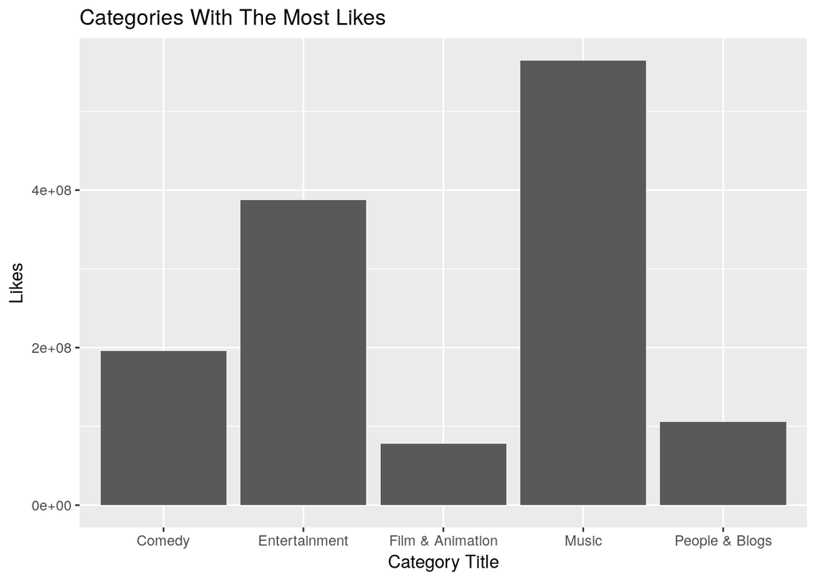

```r
most_likes = function(data){
  df = data %>%
  select(category_title, views, likes, dislikes, comment_count) %>%
  drop_na() %>%
  dplyr::group_by(category_title) %>%
  dplyr::summarize(likes = sum(likes)) %>%
  arrange(desc(likes)) %>%
  top_n(n=5)

  ggplot(df, aes(x=category_title,y=likes)) +
  geom_col() +
  ggtitle("Categories With The Most Likes") +
  xlab("Category Title") +
  ylab("Likes")
}

##Canada
most_likes(ca_data)
```

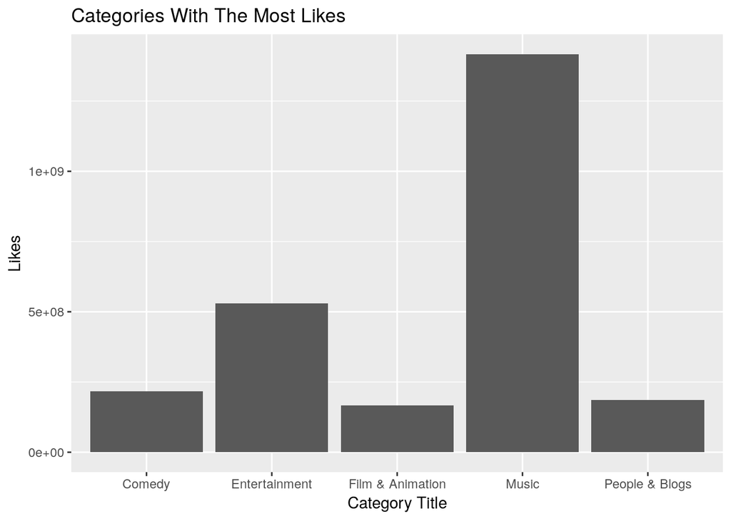

```r
##US
most_likes(us_data)
```

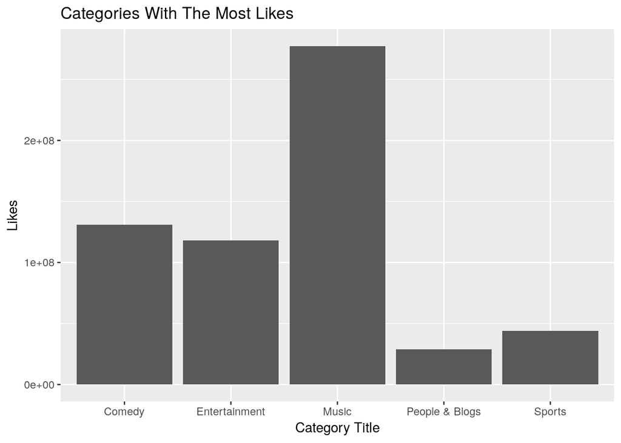

```r
##France
most_likes(fr_data)
```

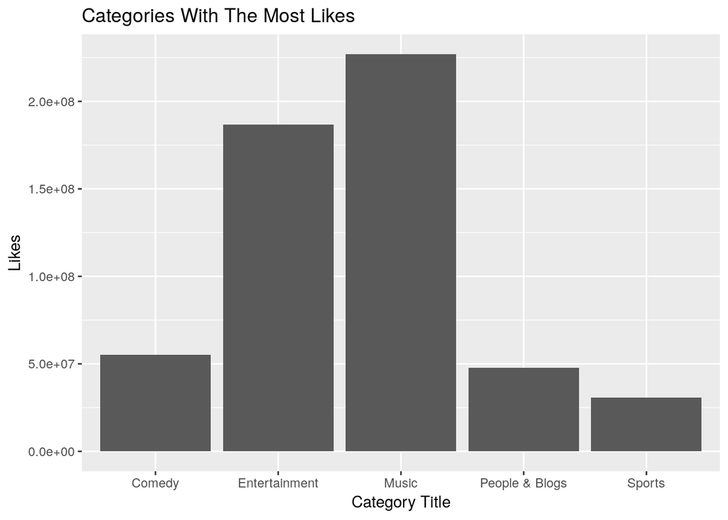

```r
## Mexico
most_likes(mx_data)
```

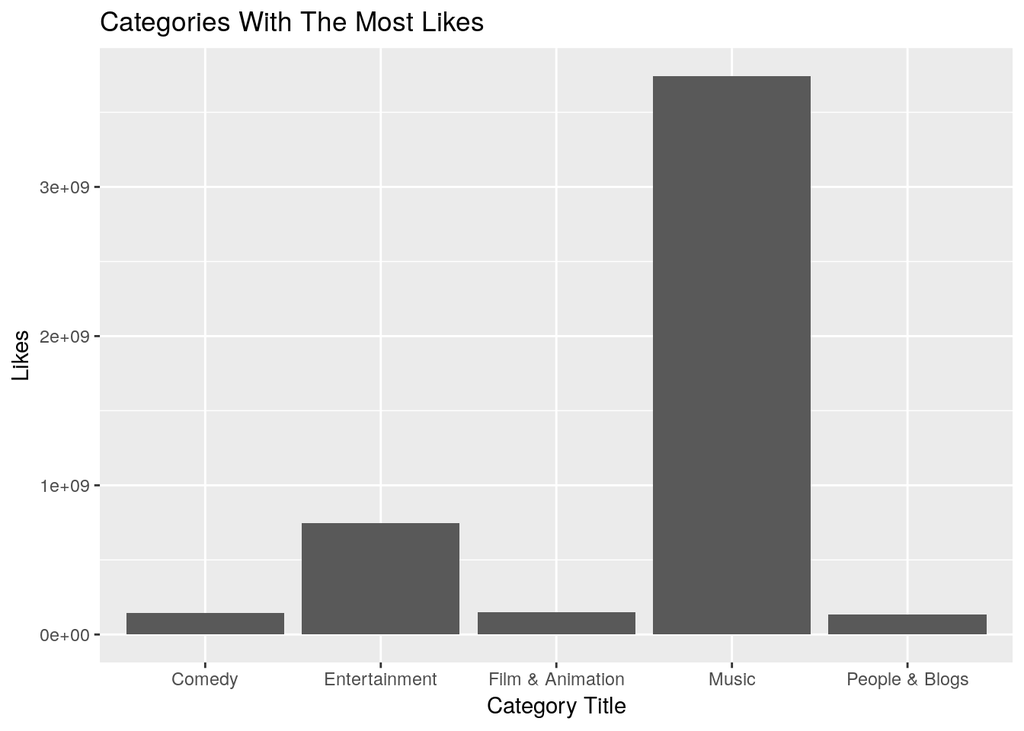

```r
##Great Britain
most_likes(gb_data)
```

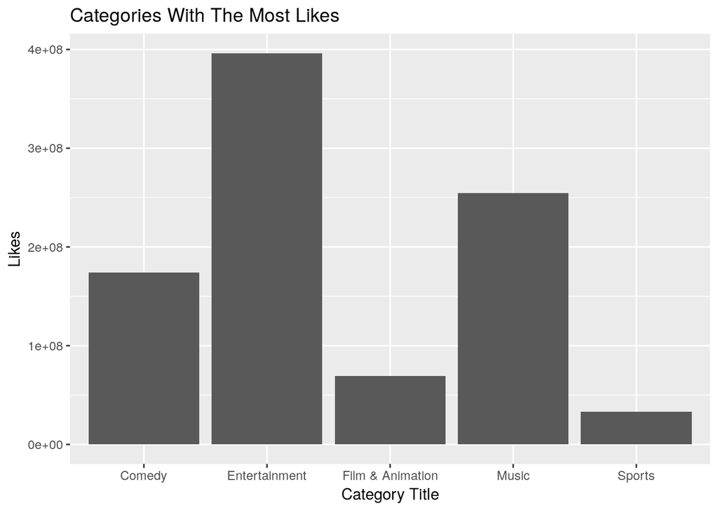

```r
##India
most_likes(in_data)
```

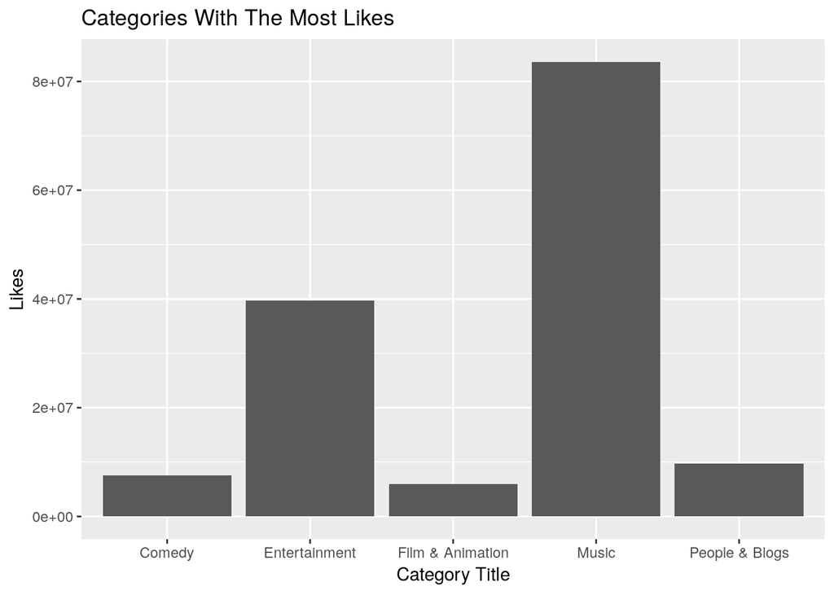

```r
## Japan
most_likes(jp_data)
```

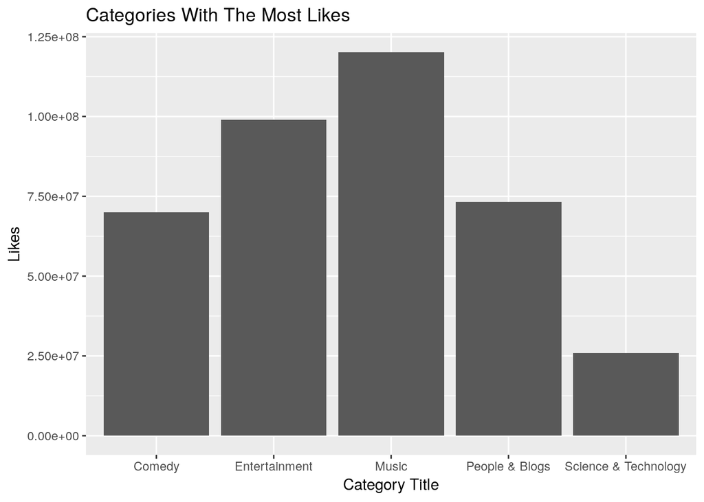

```r
## Russia
most_likes(ru_data)
```

```r
## All combined
all_countries = bind_rows(fr_data, ca_data, us_data, mx_data, jp_data, ru_data, in_data, gb_data)
print("All Countries Combined")
```

```
## [1] "All Countries Combined"
```

```r
all_countries %>%
  select(channel_title, category_title, views, likes, dislikes, comment_count) %>%
  drop_na() %>%
  dplyr::group_by(category_title) %>%
  dplyr::summarize(likes = sum(likes)) %>%
  arrange(desc(likes)) %>%
  top_n(n=5)
```

```
## # A tibble: 5 x 2
##   category_title        likes
##   <chr>                 <dbl>
## 1 Music            6686661907
## 2 Entertainment    2501757124
## 3 Comedy            993494421
## 4 People & Blogs    610300718
## 5 Film & Animation  528077118
```

### 2

> Which categories have the most comments?

-Repeat number 1 with comments

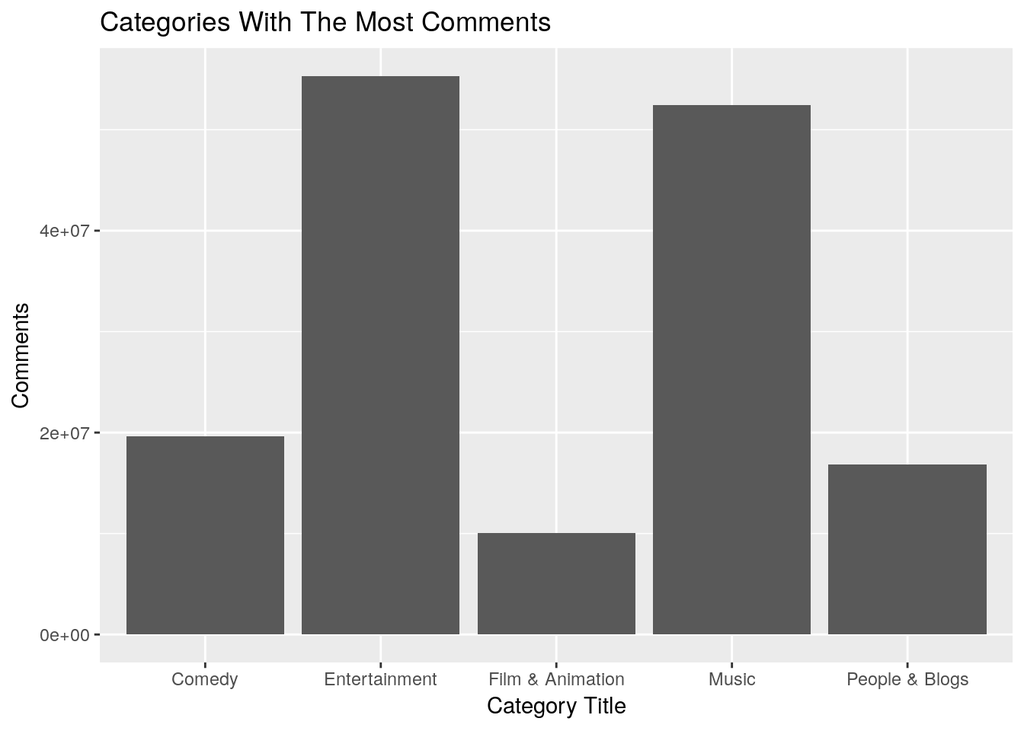

```r
most_comments = function(data){
  df = data %>%
  select(channel_title, category_title, views, likes, dislikes, comment_count) %>%
  drop_na() %>%
  dplyr::group_by(category_title) %>%
  dplyr::summarize(comment_count = sum(comment_count)) %>%
  arrange(desc(comment_count)) %>%
  top_n(n=5)

  ggplot(df, aes(x=category_title,y=comment_count)) +
  geom_col() +
  ggtitle("Categories With The Most Comments") +
  xlab("Category Title") +
  ylab("Comments")
}

##Canada
most_comments(ca_data)
```

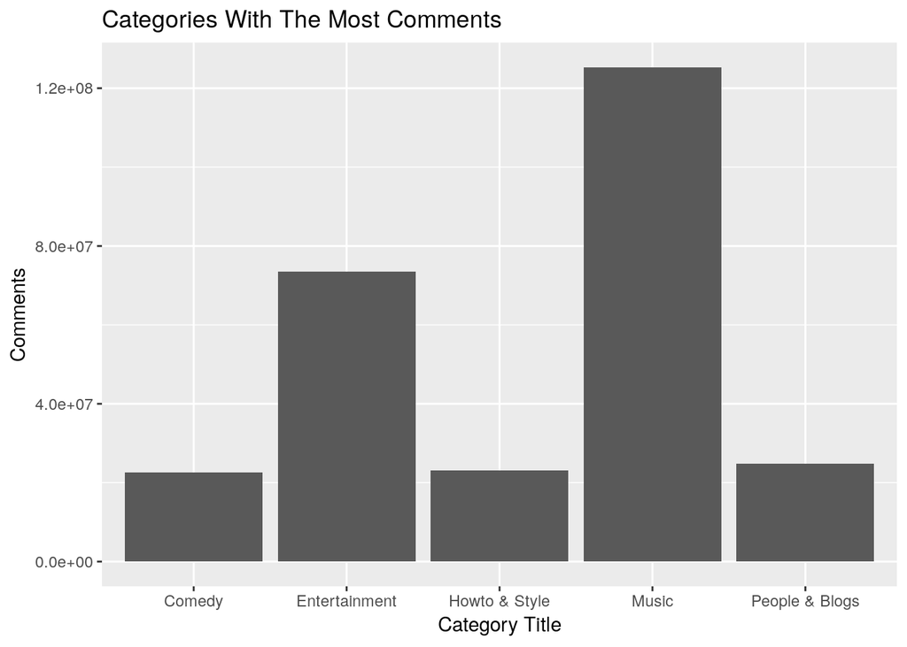

```r
##US
most_comments(us_data)
```

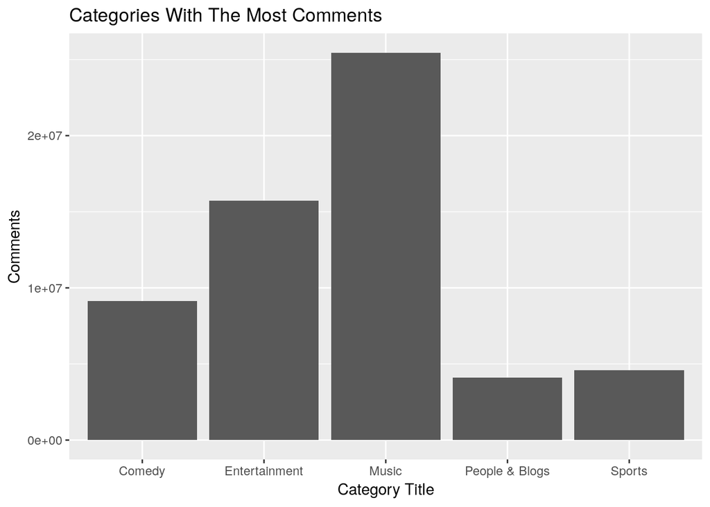

```r
##France
most_comments(fr_data)
```

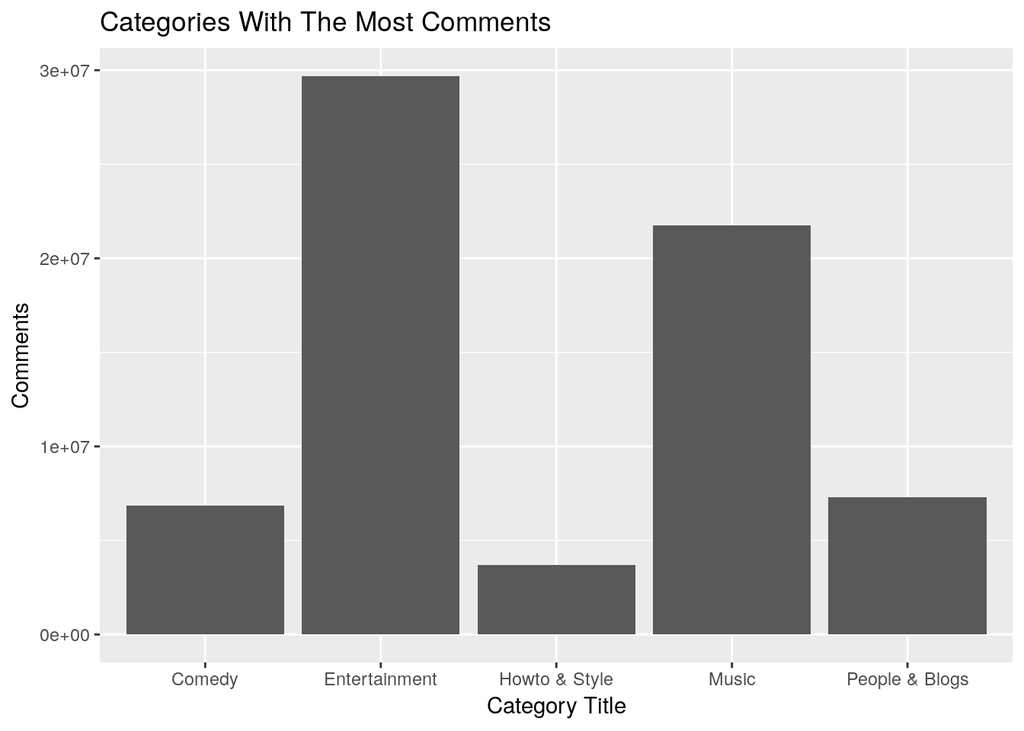

```r
## Mexico
most_comments(mx_data)
```

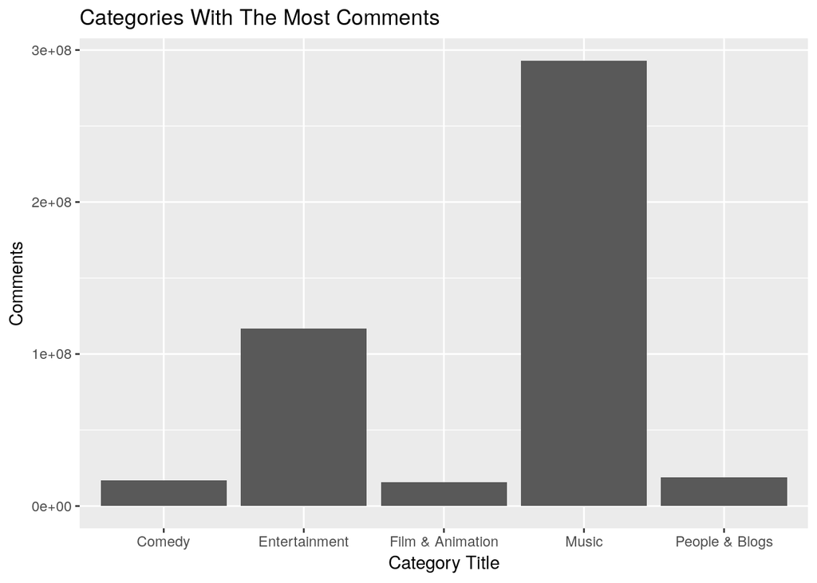

```r
##Great Britain
most_comments(gb_data)
```

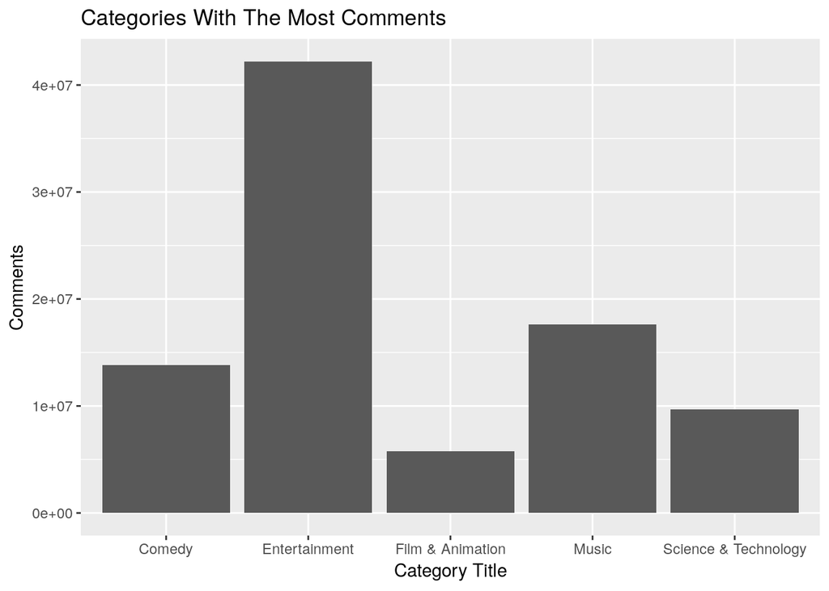

```r
##India
most_comments(in_data)
```

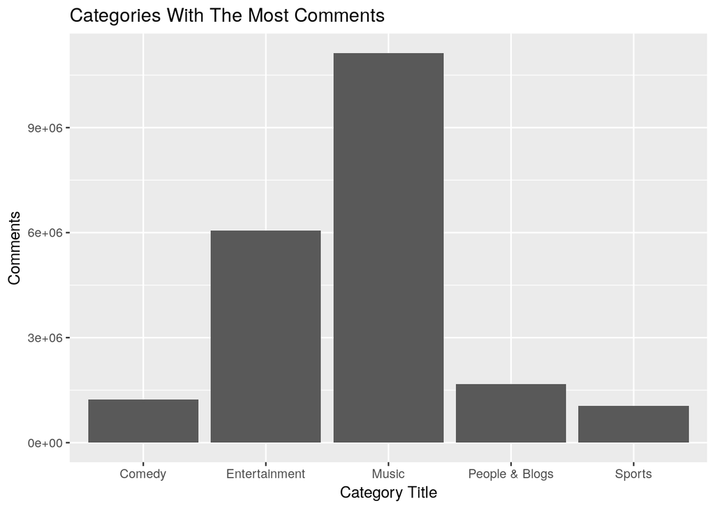

```r
## Japan
most_comments(jp_data)
```

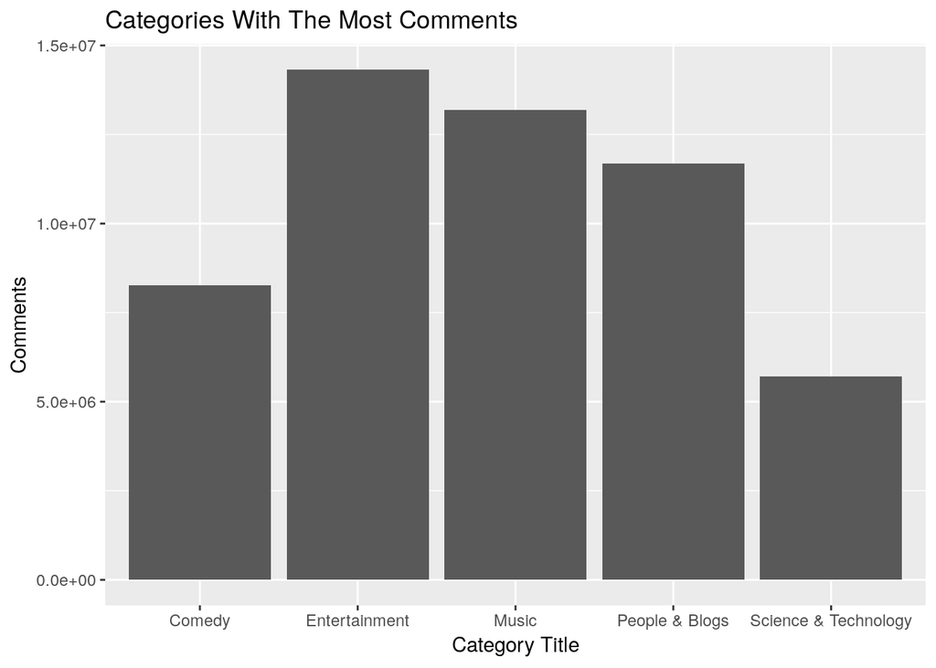

```r
## Russia
most_comments(ru_data)
```

```r
# All countries combined
print("All Countries Combined")
```

```
## [1] "All Countries Combined"
```

```r
all_countries %>%
  select(channel_title, category_title, views, likes, dislikes, comment_count) %>%
  drop_na() %>%
  dplyr::group_by(category_title) %>%
  dplyr::summarize(comment_count = sum(comment_count)) %>%
  arrange(desc(comment_count)) %>%
  top_n(n=5)%>%
  print()
```

```
## # A tibble: 5 x 2
##   category_title   comment_count
##   <chr>                    <dbl>
## 1 Music                559858268
## 2 Entertainment        353771715
## 3 Comedy                98184597
## 4 People & Blogs        87744783
## 5 Film & Animation      57262381
```

Similar the the earlier question, Music and Entertainment have a consistent presence in the top 3 categories. People & Blogs is also a common category in the top 3. This is most likely due to the more interactive relationship between the youtubers and their audience in this category.

### 3

> Are there any trending videos with more dislikes than likes? If so, how many? What categories are most common in this case?

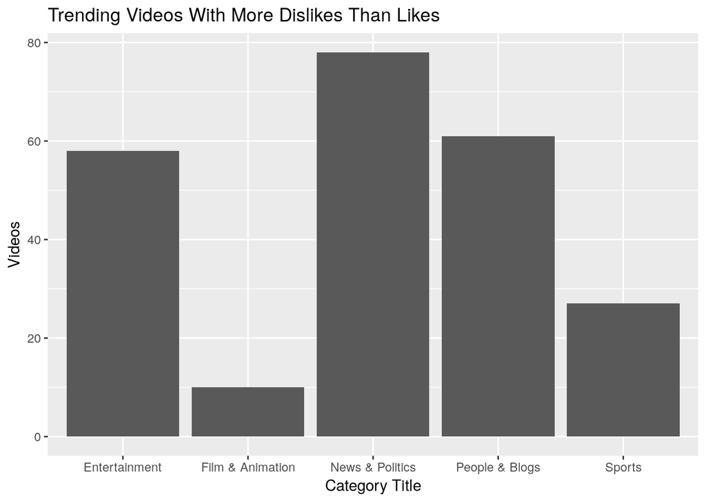

```r
more_dislikes = function(data){
  df = data %>%
  select(channel_title, category_title, views, likes, dislikes, comment_count) %>%
  drop_na() %>%
  dplyr::filter(dislikes>likes) %>%
  dplyr::group_by(category_title) %>%
  dplyr::summarize(n=n()) %>%
  arrange(desc(n)) %>%
    top_n(n=5)

ggplot(df, aes(x=category_title,y=n)) +
  geom_col() +
  ggtitle("Trending Videos With More Dislikes Than Likes") +
  xlab("Category Title") +
  ylab("Videos")
}

##Canada
more_dislikes(ca_data)
```

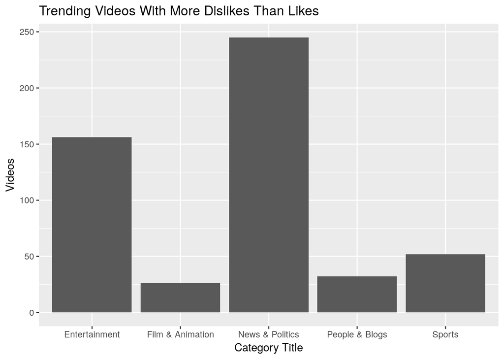

```r
##US
more_dislikes(us_data)
```

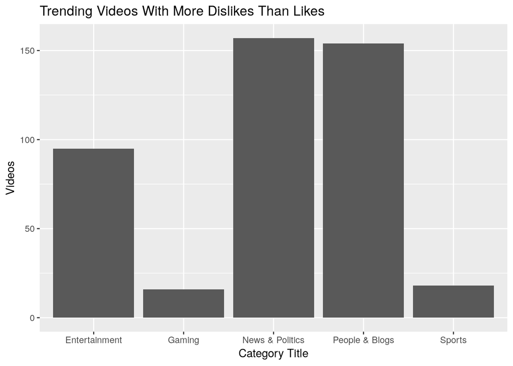

```r
##France
more_dislikes(fr_data)
```

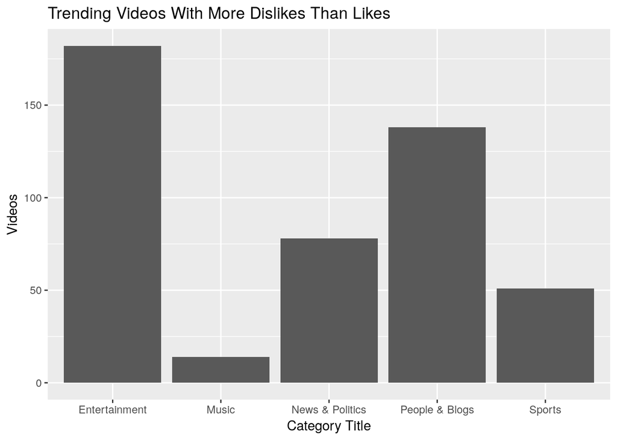

```r
## Mexico
more_dislikes(mx_data)
```

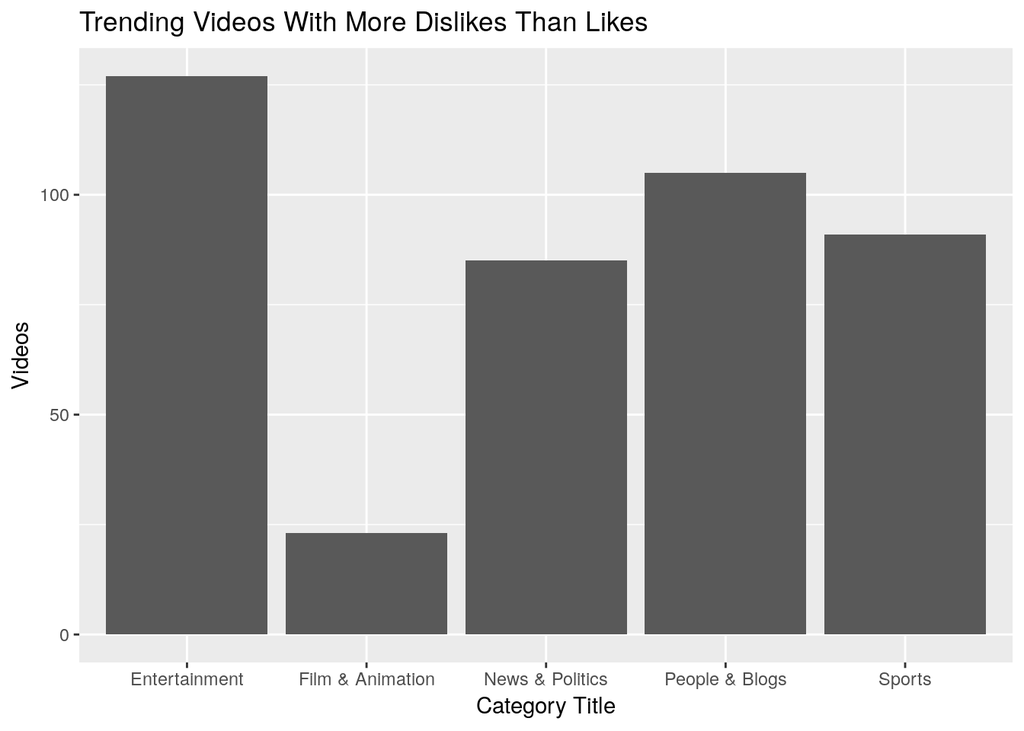

```r
##Great Britain
more_dislikes(gb_data)
```

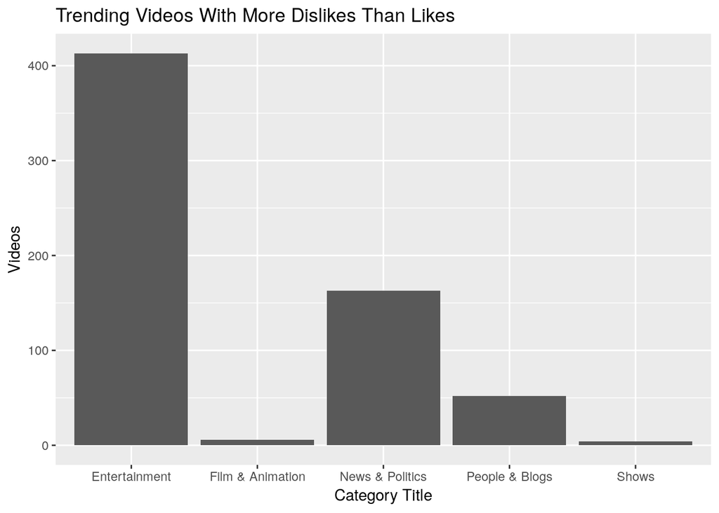

```r
##India
more_dislikes(in_data)
```

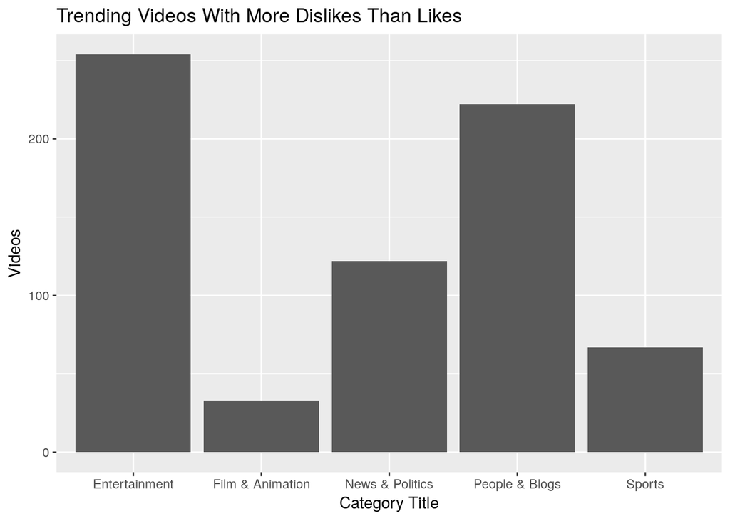

```r
## Japan
more_dislikes(jp_data)
```

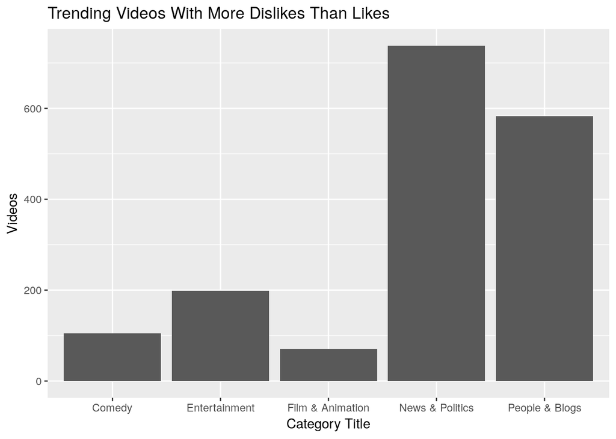

```r
## Russia
more_dislikes(ru_data)
```

### Clickbait

We generally defined clickbait as any video with a title meeting any of the following criteria: it contains no lowercase letters, it contains 8 or more characters in a row that are either whitespace, an exclamation point, or a capital letter, or it contains a “?!” or “!?”. There are a few exceptions to these rules, but those are not too common.

```r
# things that could get caught by clickbait unfairly
deceptive = "BREAKING|CONAN|SPOILERS|IFC Films|RIVERDALE|PRESHOW|WIRED"

clickbait_parse = function(df){
  df = df %>%
    mutate(clickbait = case_when(
      str_detect(title, deceptive) ~ FALSE,
      str_detect(title, "^\\d+$") ~ FALSE,
      str_detect(title, "^[^a-z]+$") ~ TRUE,
      str_detect(title, "[A-Z\\s!]{8,}") ~ TRUE,
      str_detect(title, "\\? ?!") ~ TRUE,
      str_detect(title, "! ?\\?") ~ TRUE,
      TRUE ~ FALSE
    ))
  return(df)
}

# may have to figure out other languages later
US = clickbait_parse(US)
FR = clickbait_parse(FR)
GB = clickbait_parse(GB)
CA = clickbait_parse(CA)
MX = clickbait_parse(MX)
```

### 4

> How prevalent is clickbait? How do the average number of views vary?

```r
clickbait_sum = function(data){
  df = data %>%
  dplyr::group_by(clickbait) %>%
  dplyr::summarize(n = n(),
            total_views = sum(views),
            average_views = mean(views)) %>%
  mutate(percent = n / sum(n))

  return(df)
}

bind_clickbait_sums = function(){
  US_cbsum = clickbait_sum(US) %>%
   mutate(country = "USA")

  FR_cbsum = clickbait_sum(FR) %>%
    mutate(country = "France")

  GB_cbsum = clickbait_sum(GB) %>%
    mutate(country = "Great Britain")

  MX_cbsum = clickbait_sum(MX) %>%
    mutate(country = "Mexico")

  CA_cbsum = clickbait_sum(CA) %>%
    mutate(country = "Canada")

  clickbait_sums = bind_rows(US_cbsum, FR_cbsum, GB_cbsum, MX_cbsum, CA_cbsum)

  return(clickbait_sums)
}

clickbait_sums = bind_clickbait_sums() %>%
  select(country, everything())
clickbait_sums
```

```
## # A tibble: 10 x 6
##    country       clickbait     n  total_views average_views percent
##    <chr>         <lgl>     <int>        <dbl>         <dbl>   <dbl>
##  1 USA           FALSE     32596  80939889704      2483123.   0.807
##  2 USA           TRUE       7775  14791744748      1902475.   0.193
##  3 France        FALSE     21567  11795896753       546942.   0.572
##  4 France        TRUE      16134   4797605493       297360.   0.428
##  5 Great Britain FALSE     30575 204103753458      6675511.   0.799
##  6 Great Britain TRUE       7684  24310529276      3163786.   0.201
##  7 Mexico        FALSE     21622   9342825437       432098.   0.599
##  8 Mexico        TRUE      14463   3963879831       274070.   0.401
##  9 Canada        FALSE     28660  36068708375      1258503.   0.725
## 10 Canada        TRUE      10855  10101277527       930564.   0.275
```

Clickbait seems to be the more prevalent in France and Mexico (about 40% of trending videos are clickbait) and less prevalent in the US and Great Britain (about 20% of trending videos are clickbait).

### 5

> How well do people receive clickbait?

#### Hypothesis Tests for difference in Likes/(Likes + Dislikes)

$$H_0: p_C = p_N \\
H_A: p_C \neq p_N$$

```r
Lprop_test = function(data, type = "clickbait"){
  df = clickbait_parse(data)

  cb_L = df %>%
    group_by(clickbait) %>%
    summarize(n = n(),
              p_L = sum(likes) / (sum(likes) + sum(dislikes)) )

  comm_L = df %>%
    group_by(comments_disabled) %>%
    summarize(n = n(),
              p_L = sum(likes) / (sum(likes) + sum(dislikes)) )

  if(type == "comments") {
    use = comm_L
  } else{
    use = cb_L
  }

  # values for clickbait vids (or comments disabled vids)
  p1 = use$p_L[2]
  n1 = use$n[2]
  # values for non-clickbait vids (or comments enabled vids)
  p2 = use$p_L[1]
  n2 = use$n[1]
  # combinationy
  p_pool = ((p1*n1) + (p2*n2)) / (n1 + n2)
  se_diff = sqrt( p_pool*(1-p_pool) * (1/n1 + 1/n2) )

  z_L = (p1 - p2) / se_diff
  p_L = 1 - pnorm(abs(z_L))

  if(type == "comments"){
    result = tibble(
      enabled_Lprop_greater = z_L < 0,
      z_score = abs(z_L),
      p_value = p_L
    )
  } else{
    result = tibble(
      cb_Lprop_greater = z_L > 0,
      z_score = abs(z_L),
      p_value = p_L
    )
  }

  return(result)
}

bind_Lprop_tests = function(){
  US_L = Lprop_test(US) %>%
    mutate(country = "USA")
  FR_L = Lprop_test(FR) %>%
    mutate(country = "France")
  GB_L = Lprop_test(GB) %>%
    mutate(country = "Great Britain")
  MX_L = Lprop_test(MX) %>%
    mutate(country = "Mexico")
  CA_L = Lprop_test(CA) %>%
    mutate(country = "Canada")

  Lprop_tests = bind_rows(US_L, FR_L, GB_L, MX_L, CA_L)

  return(Lprop_tests)
}
Lprop_tests = bind_Lprop_tests()

Lprop_tests
```

```
## # A tibble: 5 x 4
##   cb_Lprop_greater z_score  p_value country
##   <lgl>              <dbl>    <dbl> <chr>
## 1 TRUE                5.87 2.21e- 9 USA
## 2 TRUE                7.76 4.33e-15 France
## 3 TRUE                7.48 3.74e-14 Great Britain
## 4 TRUE                7.84 2.22e-15 Mexico
## 5 TRUE                5.98 1.14e- 9 Canada
```

For the tests for a difference in the proportion of likes/(likes + dislikes) in clickbait vs non-clickbait videos in these 5 countries, our p-values are approximately 0, which are highly statistically significant. We therefore have very convincing evidence that the proportion of likes/(likes + dislikes) is higher for clickbait videos than for non-clickbait videos in those 5 countries.

This means that out of the people that feel strongly enough about a video to either like it or dislike it, a higher proportion of people like clickbait videos than like non-clickbait videos.

### 6

> Which categories are clickbait the most frequently in each country?

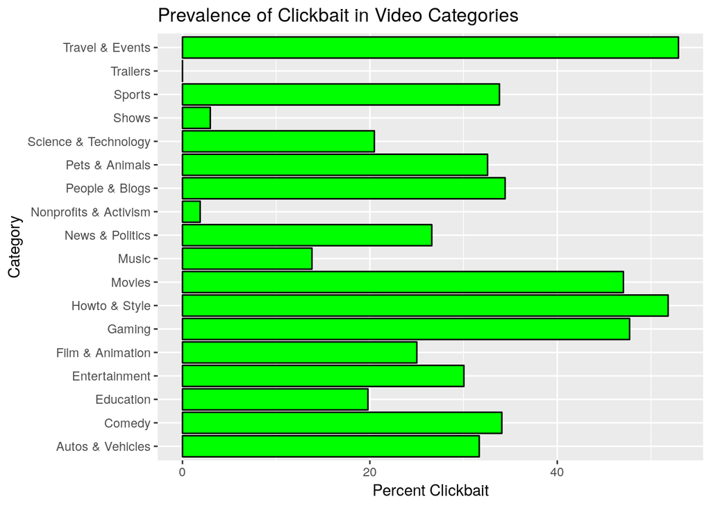

```r
clickbait_cats = function(data){
  df = clickbait_parse(data) %>%
    mutate(category_id = as.character(category_id)) %>%
    dplyr::group_by(category_title) %>%
    dplyr::summarize(n = n(),
              n_clickbait = sum(clickbait),
              p_clickbait = n_clickbait / n)
}

bind_clickbait_cats = function(){
  US_cats = clickbait_cats(US) %>%
    mutate(country = "US")
  FR_cats = clickbait_cats(FR) %>%
    mutate(country = "FR")
  GB_cats = clickbait_cats(GB) %>%
    mutate(country = "GB")
  MX_cats = clickbait_cats(MX) %>%
    mutate(country = "MX")
  CA_cats = clickbait_cats(CA) %>%
    mutate(country = "CA")

  clickbait_cats = bind_rows(US_cats, FR_cats, GB_cats, MX_cats, CA_cats)

  return(clickbait_cats)
}

clickbait_cats = bind_clickbait_cats()

# overall
clickbait_cats %>%
  dplyr::group_by(category_title) %>%
  dplyr::summarize(n = sum(n),
            n_clickbait = sum(n_clickbait),
            p_clickbait = n_clickbait / n) %>%
  ggplot(aes(x = category_title, y = 100*p_clickbait)) +
  geom_col(color = "black", fill = "green") +
  xlab("Category") +
  ylab("Percent Clickbait") +
  ggtitle("Prevalence of Clickbait in Video Categories") +
  coord_flip()
```

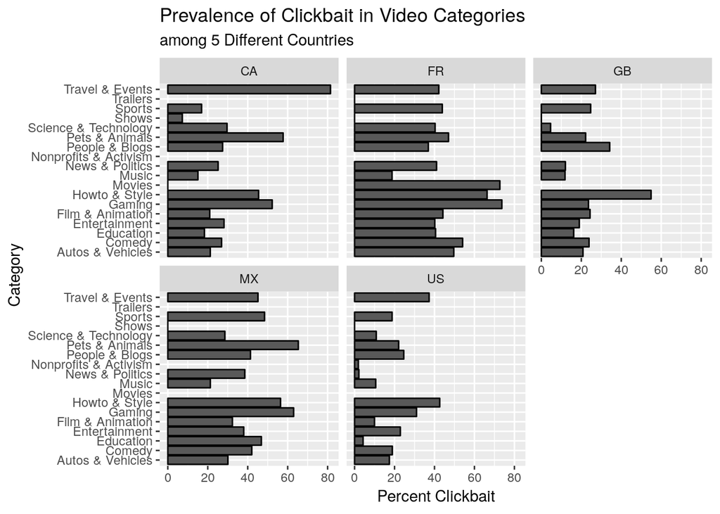

```r
# compare categories within each country
# fill = country is breaking
ggplot(clickbait_cats, aes(x = category_title, y = 100*p_clickbait)) +
  geom_col(color = "black") +
  facet_wrap(~country) +
  xlab("Category") +
  ylab("Percent Clickbait") +
  ggtitle("Prevalence of Clickbait in Video Categories",
          "among 5 Different Countries") +
  coord_flip()
```

Movies, how-to & style, gaming, and travel & events tend to be clickbait the most frequently. A typical frequency of clickbait for a video category would be around 20-40%, with categories trailers, nonprofits/activism, and shows having clickbait the least frequently (less than 3% of videos in those categories are clickbait.)

In most video categories, France and Mexico have clickbait videos more frequently. The margin for this differs across categories, and it varies across categories whether France or Mexico has a higher clickbait frequency. In some categories, Canada has a higher frequency of clickbait as well.

### Trending Channels and Categories

### 7

> Do the same channels trend in each country?
- Filter each data set to include only channel titles and views.
- Determine the top 10 channels that trend in each country by summing up the views and arranging them by number of views.

```r
channel_trend = function(data){
  df = data %>%
  select(channel_title, views) %>%
  drop_na() %>%
  group_by(channel_title) %>%
  summarize(views = sum(views)) %>%
  arrange(desc(views)) %>%
  top_n(n=10) %>%
  print()
}

## Canada
channel_trend(ca_data)
```

```
## # A tibble: 10 x 2
##    channel_title                    views
##    <chr>                            <dbl>
##  1 Marvel Entertainment        1011420205
##  2 T-Series                     799114025
##  3 Dude Perfect                 729916338
##  4 YouTube Spotlight            635976769
##  5 ibighit                      511567918
##  6 PewDiePie                    461700524
##  7 Sony Pictures Entertainment  451188760
##  8 Speed Records                426604974
##  9 20th Century Fox             419577035
## 10 ChildishGambinoVEVO          411775069
```

```r
## France
channel_trend(fr_data)
```

```
## # A tibble: 10 x 2
##    channel_title            views
##    <chr>                    <dbl>
##  1 Dude Perfect         305226697
##  2 ibighit              291768132
##  3 YouTube Spotlight    254422431
##  4 PewDiePie            243522111
##  5 Marvel Entertainment 223358474
##  6 TaylorSwiftVEVO      174371361
##  7 MLG Highlights       163697067
##  8 Çukur                163668822
##  9 ChildishGambinoVEVO  153765066
## 10 Ed Sheeran           147303194
```

```r
## Great Britain
channel_trend(gb_data)
```

```
## # A tibble: 10 x 2
##    channel_title             views
##    <chr>                     <dbl>
##  1 NickyJamTV           8516190092
##  2 Ozuna                8305198063
##  3 Bad Bunny            6891280759
##  4 DrakeVEVO            6581834413
##  5 ChildishGambinoVEVO  6101309613
##  6 Flow La Movie        5151438858
##  7 ArianaGrandeVevo     4107436350
##  8 Marvel Entertainment 3993421220
##  9 jypentertainment     3624070589
## 10 Ed Sheeran           3589056783
```

```r
## India
channel_trend(in_data)
```

```
## # A tibble: 10 x 2
##    channel_title                    views
##    <chr>                            <dbl>
##  1 T-Series                    2124607907
##  2 Marvel Entertainment        1280396202
##  3 FoxStarHindi                1260807619
##  4 Amit Bhadana                1024252169
##  5 Speed Records                801739414
##  6 Sony Pictures Entertainment  772261898
##  7 Zee Music Company            694640267
##  8 Goldmines Telefilms          643826504
##  9 Dude Perfect                 598578613
## 10 YRF                          573884674
```

```r
## Japan
channel_trend(jp_data)
```

```
## # A tibble: 10 x 2
##    channel_title                   views
##    <chr>                           <dbl>
##  1 ibighit                     338728753
##  2 Marvel Entertainment        153285154
##  3 MLG Highlights              106078533
##  4 Sony Pictures Entertainment  90070123
##  5 SpaceX                       84901008
##  6 TaylorSwiftVEVO              78166154
##  7 東海オンエア                 74293753
##  8 水溜りボンド                 70939666
##  9 Sơn Tùng M-TP Official       68327404
## 10 Fischer's-フィッシャーズ-    63393802
```

```r
## Mexico
channel_trend(mx_data)
```

```
## # A tibble: 10 x 2
##    channel_title            views
##    <chr>                    <dbl>
##  1 Marvel Entertainment 383058026
##  2 YouTube Spotlight    255273304
##  3 ibighit              251466087
##  4 MalumaVEVO           226697506
##  5 Dude Perfect         172934487
##  6 NickyJamTV           162371871
##  7 DrossRotzank         160722189
##  8 PewDiePie            154828754
##  9 Ozuna                144610384
## 10 Cracks               143870186
```

```r
## Russia
channel_trend(ru_data)
```

```
## # A tibble: 10 x 2
##    channel_title             views
##    <chr>                     <dbl>
##  1 ibighit               238699889
##  2 Трум Трум             178367393
##  3 PewDiePie             145729987
##  4 вДудь                 127282959
##  5 Алексей Навальный     125499738
##  6 SlivkiShow            123175267
##  7 Wylsacom              112156010
##  8 SOBOLEV               101953840
##  9 Мастерская Настроения  90552175
## 10 AcademeG               88411224
```

```r
## USA
channel_trend(us_data)
```

```
## # A tibble: 10 x 2
##    channel_title                    views
##    <chr>                            <dbl>
##  1 ChildishGambinoVEVO         3758488765
##  2 ibighit                     2235906679
##  3 Dude Perfect                1870085178
##  4 Marvel Entertainment        1808998971
##  5 ArianaGrandeVevo            1576959172
##  6 MalumaVEVO                  1551515831
##  7 jypentertainment            1486972132
##  8 Sony Pictures Entertainment 1432374398
##  9 FoxStarHindi                1238609854
## 10 BeckyGVEVO                  1182971286
```

After comparing the top 10 most popular trending channels in each of the 8 countries, we found that there are no channels that trend in the top 10 of every country. There are a couple channels that trend in more than one country. Marvel Entertainment trends in 7 of the countries, making it the most popular amongst all 8 countries. The next most popular channel is ibighit, trending in 6 countries. Dude Perfect trends in 5, and PewDiePie, Sony Pictures Entertainment, and ChildishGambinoVEVO all trend in 4. To better compare trending channels, we took the 6 most popular trending channels amongst the countries and plotted them below.

```r
channel_trend2 = function(data){
    df = data %>%
  select(channel_title, views) %>%
  drop_na() %>%
  group_by(channel_title) %>%
  summarize(views = sum(views)) %>%
      top_n(n=10)
}

bind_channel_trend2 = function(){
  US_channel = channel_trend2(us_data) %>%
    mutate(country = "US")
  FR_channel = channel_trend2(fr_data) %>%
    mutate(country = "FR")
  GB_channel = channel_trend2(gb_data) %>%
    mutate(country = "GB")
  MX_channel = channel_trend2(mx_data) %>%
    mutate(country = "MX")
  RU_channel = channel_trend(ru_data) %>%
    mutate(country = "RU")
  CA_channel = channel_trend2(ca_data) %>%
    mutate(country = "CA")
  IN_channel = channel_trend2(in_data) %>%
    mutate(country = "IN")
  JP_channel = channel_trend2(jp_data) %>%
    mutate(country = "JP")


  channel_trend2 = bind_rows(US_channel, FR_channel, GB_channel, MX_channel,
                             CA_channel, IN_channel, JP_channel, RU_channel)

  return(channel_trend2)
}

channel_trend2 = bind_channel_trend2()
```

```
## # A tibble: 10 x 2
##    channel_title             views
##    <chr>                     <dbl>
##  1 ibighit               238699889
##  2 Трум Трум             178367393
##  3 PewDiePie             145729987
##  4 вДудь                 127282959
##  5 Алексей Навальный     125499738
##  6 SlivkiShow            123175267
##  7 Wylsacom              112156010
##  8 SOBOLEV               101953840
##  9 Мастерская Настроения  90552175
## 10 AcademeG               88411224
```

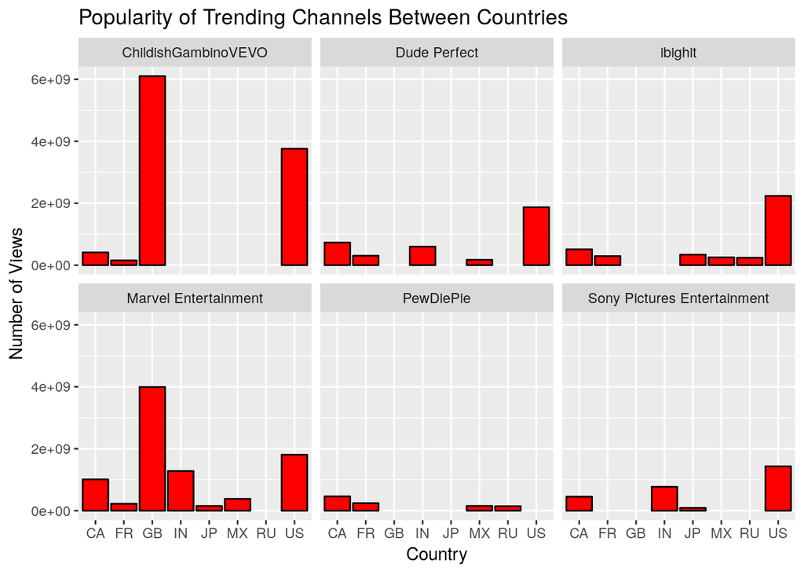

```r
channel_trend3 = channel_trend2 %>%
  filter(channel_title == 'Marvel Entertainment' |
           (channel_title == 'PewDiePie') |
           (channel_title == 'Dude Perfect') |
           (channel_title == 'ibighit') |
           (channel_title == 'Sony Pictures Entertainment') |
           (channel_title == 'ChildishGambinoVEVO'))

# plot comparing popular channels among the 8 countries
ggplot(channel_trend3, aes(x = country, y = views)) +
  geom_col(fill = "red", color = "black") +
  facet_wrap(~channel_title) +
  xlab("Country") +
  ylab("Number of Views") +
  ggtitle("Popularity of Trending Channels Between Countries")
```

### 8

> Do the same categories trend in each country?
- Same steps at question 7, but with categories instead of channels.

```r
category_trend = function(data){
  df = data %>%
  select(category_title, views) %>%
  drop_na() %>%
  group_by(category_title) %>%
  summarize(views = sum(views)) %>%
  arrange(desc(views)) %>%
  top_n(n=10) %>%
    print()
}

## Canada
category_trend(ca_data)
```

```
## # A tibble: 10 x 2
##    category_title             views
##    <chr>                      <dbl>
##  1 Entertainment        13671215509
##  2 Music                13179850194
##  3 Comedy                3708438785
##  4 People & Blogs        3228227926
##  5 Sports                2997652188
##  6 Film & Animation      2939060844
##  7 News & Politics       1614610043
##  8 Howto & Style         1570846611
##  9 Science & Technology  1425090421
## 10 Gaming                1241532385
```

```r
## France
category_trend(fr_data)
```

```
## # A tibble: 10 x 2
##    category_title            views
##    <chr>                     <dbl>
##  1 Music                5026447522
##  2 Entertainment        3779500229
##  3 Sports               1996811039
##  4 Comedy               1896284649
##  5 People & Blogs       1280843533
##  6 Film & Animation      918517018
##  7 News & Politics       495045563
##  8 Howto & Style         468344413
##  9 Science & Technology  461992294
## 10 Gaming                447160176
```

```r
## Great Britain
category_trend(gb_data)
```

```
## # A tibble: 10 x 2
##    category_title              views
##    <chr>                       <dbl>
##  1 Music                171160864769
##  2 Entertainment         29786283041
##  3 Film & Animation       8362707626
##  4 People & Blogs         5754287829
##  5 Comedy                 3962062143
##  6 Sports                 3341736194
##  7 Gaming                 1746619532
##  8 Science & Technology   1641388256
##  9 News & Politics        1409131375
## 10 Howto & Style          1190155227
```

```r
## India
category_trend(in_data)
```

```
## # A tibble: 10 x 2
##    category_title             views
##    <chr>                      <dbl>
##  1 Entertainment        16120390974
##  2 Music                10150844485
##  3 Film & Animation      3847149504
##  4 Comedy                2887672070
##  5 News & Politics       1994263812
##  6 Sports                1379949159
##  7 People & Blogs        1364104242
##  8 Howto & Style          737343593
##  9 Science & Technology   477111016
## 10 Gaming                 274722506
```

```r
## Japan
category_trend(jp_data)
```

```
## # A tibble: 10 x 2
##    category_title            views
##    <chr>                     <dbl>
##  1 Entertainment        1766268244
##  2 Music                1070344379
##  3 People & Blogs        587487319
##  4 Sports                580726014
##  5 Film & Animation      311590772
##  6 Comedy                280973914
##  7 Science & Technology  191772211
##  8 News & Politics       186286429
##  9 Gaming                173525830
## 10 Howto & Style         108416992
```

```r
## Mexico
category_trend(mx_data)
```

```
## # A tibble: 10 x 2
##    category_title            views
##    <chr>                     <dbl>
##  1 Music                4159713283
##  2 Entertainment        4027574336
##  3 Sports               1389337978
##  4 People & Blogs       1229501908
##  5 Comedy                794647488
##  6 News & Politics       491449042
##  7 Howto & Style         465587429
##  8 Film & Animation      461919619
##  9 Gaming                421961773
## 10 Science & Technology  202863454
```

```r
## Russia
category_trend(ru_data)
```

```
## # A tibble: 10 x 2
##    category_title            views
##    <chr>                     <dbl>
##  1 Entertainment        2088743148
##  2 Music                1605269644
##  3 People & Blogs       1564739895
##  4 Comedy               1021361186
##  5 News & Politics       739248272
##  6 Film & Animation      540227680
##  7 Science & Technology  425486169
##  8 Howto & Style         386912627
##  9 Autos & Vehicles      383781815
## 10 Sports                383133314
```

```r
## USA
category_trend(us_data)
```

```
## # A tibble: 10 x 2
##    category_title             views
##    <chr>                      <dbl>
##  1 Music                40132892190
##  2 Entertainment        20604388195
##  3 Film & Animation      7284156721
##  4 Comedy                5117426208
##  5 People & Blogs        4917191726
##  6 Sports                4404456673
##  7 Howto & Style         4078545064
##  8 Science & Technology  3487756816
##  9 Gaming                2141218625
## 10 News & Politics       1473765704
```

### 9

> Does a particular time of year also have particular tags?

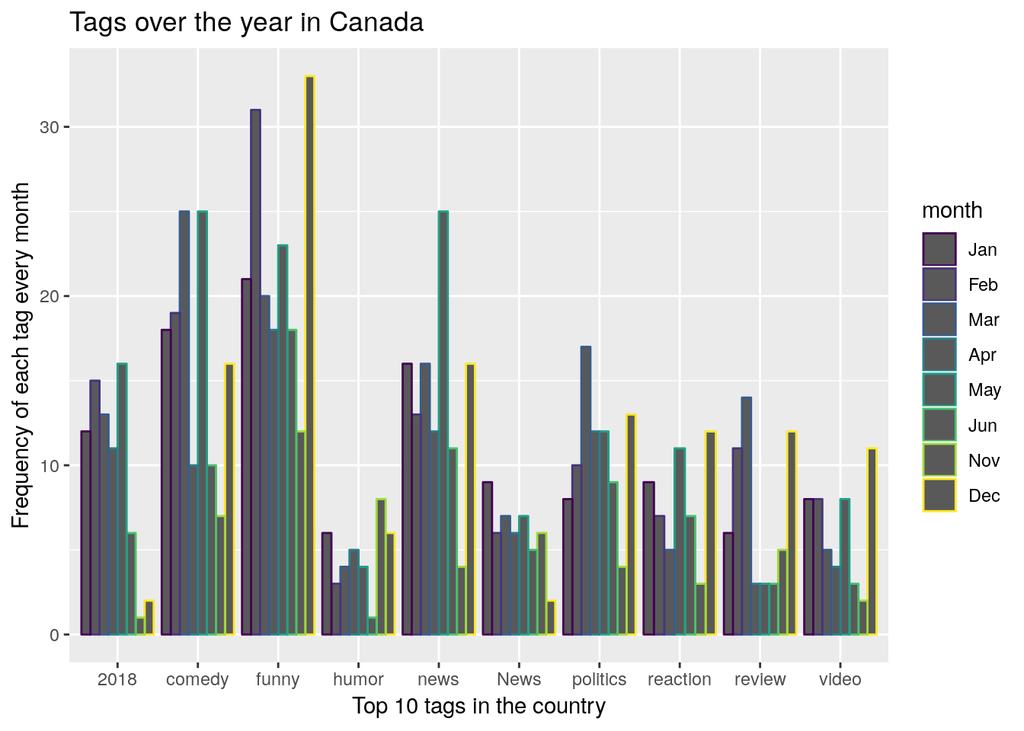

```r
split_data = function(df) {
  cSplit(df, "tags", sep="|") %>%
    select(video_id, trending_date, starts_with("tags")) %>%
    mutate(trending_date = ydm(trending_date)) %>%
    gather(starts_with("tags"), key = "num", value = "tags") %>%
    drop_na()
}

tidy_data = function(df) {
  return( split_data(df) %>%
              group_by(video_id) %>%
              distinct(num, .keep_all = TRUE)
        )
}

top_10 = function (df) {
  df = df %>%
    filter(!(tags == "[none]")) %>%
    mutate(month = month(trending_date, label = TRUE))

  temp = ddply(df,~tags,summarise,number_of_distinct=length(unique(video_id))) %>%
    arrange(desc(number_of_distinct)) %>%
    top_n(10, wt=number_of_distinct)

  df = df[unlist(sapply(1:NROW(filter), function(i)
    which(df$tags == temp$tags))),]

  return(df)
}

cumulative = function(df) {
  df = tidy_data(df)
  df = top_10(df)
  return(df)
}

plot = function(df, country_name) {
  title = paste("Tags over the year in", country_name)
  df %>%
  mutate(month = month(trending_date, label = TRUE)) %>%
  ggplot(aes(x = tags, colour = month)) +
    geom_bar(position = "dodge") +
    xlab("Top 10 tags in the country") +
    ylab("Frequency of each tag every month") +
    ggtitle(title)
}


ca_data = cumulative(ca_data)
plot(ca_data, "Canada")
```

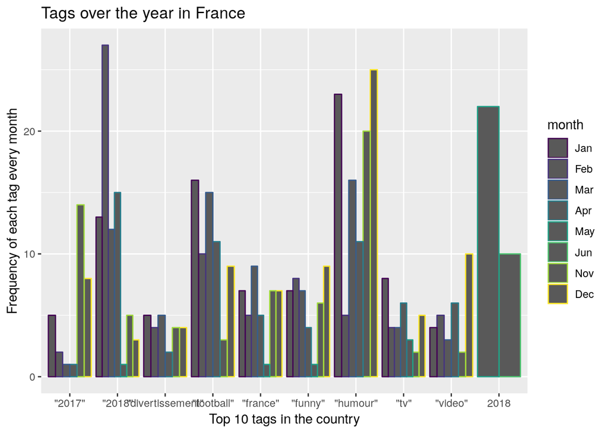

```r
fr_data = cumulative(fr_data)
plot(fr_data, "France")
```

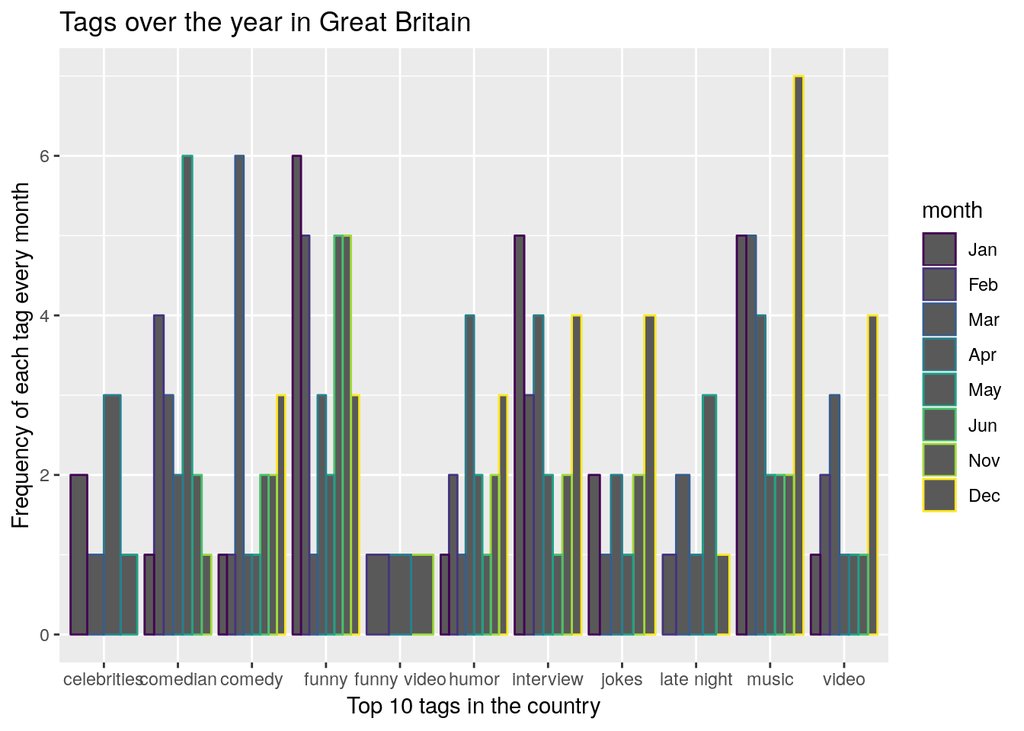

```r
gb_data = cumulative(gb_data)
plot(gb_data, "Great Britain")
```

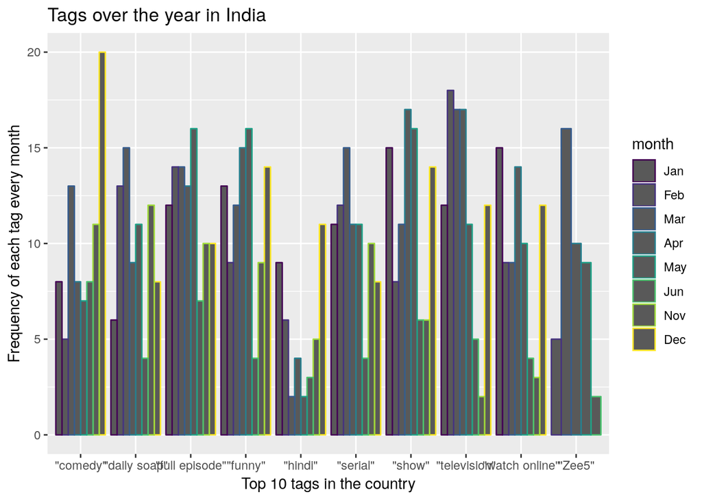

```r
in_data = cumulative(in_data)
plot(in_data, "India")
```

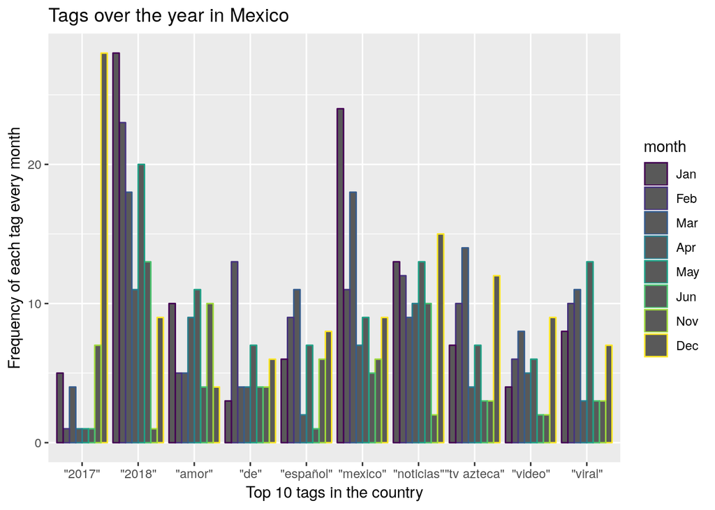

```r
mx_data = cumulative(mx_data)
plot(mx_data, "Mexico")
```

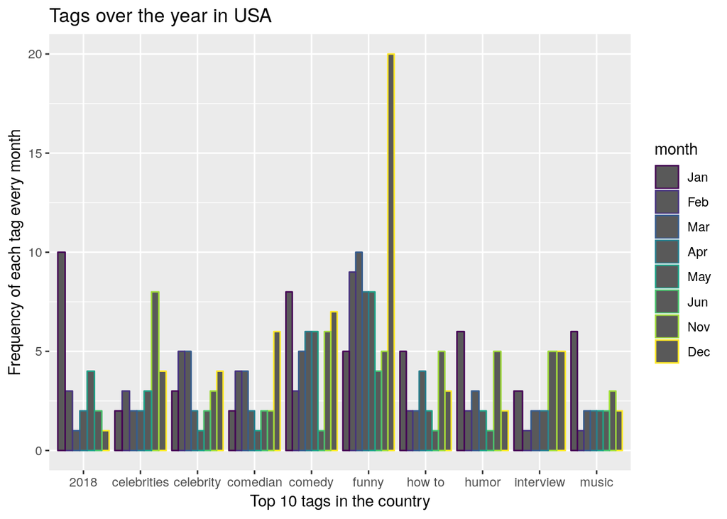

```r
us_data = cumulative(us_data)
plot(us_data, "USA")
```

## Discussion

Overall, across countries, there are many similarities about videos that are trending. The categories with the most likes and comments are similar, with music videos often being very popular. Videos about news and politics are often controversial in different countries too. In the 5 countries examined, clickbait videos tend to receive more likes/(likes+dislikes) than non-clickbait videos. This would indicate that trending clickbait videos are fairly well received in all of these countries. Additionally, many popular channels have many trending videos in more than one country, such as Marvel, Dude Perfect, and PewDiePie. Many popular video categories trend in most or all of the countries examined too, but there is variation in this trend.

There are also many differences about trending videos across countries. For example, trending videos in France and Mexico tend to be clickbait more frequently than trending videos in the US, UK, and Canada. While many channels are trendy in lots of countries, there were no channels that were in the top 10 for trending videos in all of the countries we looked at, so there is still some variation in terms of which channels are the most popular around the world.

One shortcoming of this analysis is that it uses likes and dislikes to determine whether or not a video is well received. This can be misleading because in order to like or dislike a video, a YouTube account is required, but it is possible to watch the video without an account. Most videos have many more views than likes and dislikes combined, and many people do not click like or dislike on videos, so they may be an inaccurate way to really determine whether or not most people watching a video enjoy it. We used this metric when analyzing whether or not people liked clickbait and when finding the categories with the most likes or more dislikes than likes. Another shortcoming is that our analysis for clickbait is all in terms of English, which makes it especially difficult to analyze videos in Russia, India, and Japan which often use non-English characters. We therefore excluded those countries from our clickbait analysis. It also could affect other countries if they have trending videos with non-English characters in the title.